# Pilot Version 4

DGK

Q3 2025

# Import Libraries

```r
library(tidyverse)
library(emmeans)
library(sdamr)
library(afex)
```

```r
library(ggplot2)
library(gridExtra)
library(see)
library(corrr)
library(broom)
```

# Read Data

```r
data <- read.csv("/Users/dgkamper/Library/CloudStorage/GoogleDrive-dgkamper@gmail.com/My Drive/DGK Lab/Collaborations/Causal Cognition Lab/Causal Cognition Lab; Reasoning Lab - Constrain Satisfaction Causal Models/Data/clean data.csv")

# Clean column names (remove trailing spaces)
names(data) <- trimws(names(data))

# Check data structure
str(data)
```

```
## 'data.frame':    58 obs. of  39 variables:
##  $ id              : int  52 33 42 51 3 26 28 34 36 43 ...
##  $ Prolific_ID     : chr  "62b44f66a16d45783569fad6" "58d0632c2fc72000011f8c57" "5faac85e364c744c43a54ec5" "642ee08bca2effffc9e754e2" ...
##  $ probability     : int  80 60 90 0 39 71 80 25 70 75 ...
##  $ verdict         : chr  "Guilty" "Guilty" "Guilty" "Not Guilty" ...
##  $ condition       : chr  "likelihood" "likelihood" "likelihood" "likelihood" ...
##  $ p1_likelihood_ng: int  5 10 10 10 16 20 20 20 20 25 ...
##  $ p1_likelihood_g : int  95 70 95 90 91 100 100 65 80 100 ...
##  $ p2_likelihood_ng: int  55 29 10 5 41 100 5 35 10 50 ...
##  $ p2_likelihood_g : int  45 61 96 10 57 99 100 50 70 100 ...
##  $ p3_likelihood_ng: int  65 18 5 68 29 100 50 40 30 70 ...
##  $ p3_likelihood_g : int  80 66 93 85 68 0 50 75 90 100 ...
##  $ p4_likelihood_ng: int  30 8 5 20 38 0 0 35 50 1 ...
##  $ p4_likelihood_g : int  90 74 95 100 73 100 100 70 90 100 ...
##  $ d1_likelihood_ng: int  90 50 82 100 91 22 20 65 50 50 ...
```

[output cut: 25 more lines]

```r
summary(data$condition)
```

```
##    Length     Class      Mode
##        58 character character
```

```r
summary(data$verdict)
```

```
##    Length     Class      Mode
##        58 character character
```

# Basic Descriptives

```r
# Sample sizes by condition and verdict
sample_summary <- data %>%
  group_by(condition, verdict) %>%
  summarise(n = n(), .groups = 'drop') %>%
  pivot_wider(names_from = verdict, values_from = n, values_fill = 0)

print("Sample sizes:")
```

```
## [1] "Sample sizes:"
```

```r
print(sample_summary)
```

```
## # A tibble: 2 × 3
##   condition  Guilty `Not Guilty`
##   <chr>       <int>        <int>
## 1 diagnostic     17           17
## 2 likelihood     15            9
```

```r
# Mean probability ratings by condition and verdict
prob_summary <- data %>%
  group_by(condition, verdict) %>%
  summarise(mean_prob = mean(probability, na.rm = TRUE), .groups = 'drop')

print("Mean probability of guilt by condition and verdict:")
```

```
## [1] "Mean probability of guilt by condition and verdict:"
```

```r
print(prob_summary)
```

```
## # A tibble: 4 × 3
##   condition  verdict    mean_prob
##   <chr>      <chr>          <dbl>
## 1 diagnostic Guilty          76.5
## 2 diagnostic Not Guilty      37.3
## 3 likelihood Guilty          75.1
## 4 likelihood Not Guilty      35.2
```

# Likelihood Analysis with log transformed ratios

```r
# Filter likelihood condition data
likelihood_data <- data %>% filter(condition == "likelihood")

# Evidence pieces
evidence_cols <- c("p1", "p2", "p3", "p4", "d1", "d2", "d3", "d4")

# Function to safely calculate log ratios (avoiding log(0))
safe_log_ratio <- function(numerator, denominator) {
  # Convert 0 to 0.1 and 100 to 99.9
  safe_denom <- ifelse(denominator <= 0, 0.1, ifelse(denominator >= 100, 99.9, denominator))
  safe_num <- ifelse(numerator <= 0, 0.1, ifelse(numerator >= 100, 99.9, numerator))
  return(log(safe_num / safe_denom))
}

# Calculate log likelihood ratios for each evidence piece
likelihood_log_results <- list()

for (evidence in evidence_cols) {
  # Get column names for this evidence
  g_col <- paste0(evidence, "_likelihood_g")
  ng_col <- paste0(evidence, "_likelihood_ng")

  # Calculate log ratios for each participant
  likelihood_data <- likelihood_data %>%
    mutate(!!paste0(evidence, "_log_ratio") := safe_log_ratio(!!sym(g_col), !!sym(ng_col)))

  # Calculate means by verdict
  means <- likelihood_data %>%
    group_by(verdict) %>%
    summarise(mean_log_ratio = mean(!!sym(paste0(evidence, "_log_ratio")), na.rm = TRUE),
              .groups = 'drop')

  likelihood_log_results[[evidence]] <- means
}

print("=== LIKELIHOOD LOG RATIOS ===")
```

```
## [1] "=== LIKELIHOOD LOG RATIOS ==="
```

```r
for (evidence in evidence_cols) {
  means <- likelihood_log_results[[evidence]]
  guilty_mean <- means$mean_log_ratio[means$verdict == "Guilty"]
  not_guilty_mean <- means$mean_log_ratio[means$verdict == "Not Guilty"]

  cat(sprintf("%s: Guilty = %.4f, Not Guilty = %.4f, Difference = %.4f\n",
              toupper(evidence), guilty_mean, not_guilty_mean, guilty_mean - not_guilty_mean))
}
```

```
## P1: Guilty = 1.1993, Not Guilty = 0.7380, Difference = 0.4613
## P2: Guilty = 0.9991, Not Guilty = 0.0649, Difference = 0.9342
## P3: Guilty = 0.2895, Not Guilty = 0.2785, Difference = 0.0109
## P4: Guilty = 2.3167, Not Guilty = 0.5244, Difference = 1.7923
## D1: Guilty = 0.0190, Not Guilty = -0.7580, Difference = 0.7771
## D2: Guilty = -0.2502, Not Guilty = -0.6340, Difference = 0.3838
## D3: Guilty = -1.1502, Not Guilty = -0.3117, Difference = -0.8385
## D4: Guilty = -0.5803, Not Guilty = -1.3966, Difference = 0.8163
```

# Diagnostic Analysis

```r
diagnostic_data <- data %>% filter(condition == "diagnostic")

# Calculate log diagnostic ratios: log(P(Evidence|Guilty) / P(Evidence|Not Guilty))
diagnostic_log_results <- list()

for (evidence in evidence_cols) {
  # Get column names - diagnostic uses _t (true/guilty) and _f (false/not guilty)
  t_col <- paste0(evidence, "_diagnostic_t")  # P(Evidence|Guilty)
  f_col <- paste0(evidence, "_diagnostic_f")  # P(Evidence|Not Guilty)

  # Calculate log ratios
  diagnostic_data <- diagnostic_data %>%
    mutate(!!paste0(evidence, "_log_diagnostic") := safe_log_ratio(!!sym(t_col), !!sym(f_col)))

  # Calculate means by verdict
  means <- diagnostic_data %>%
    group_by(verdict) %>%
    summarise(mean_log_diagnostic = mean(!!sym(paste0(evidence, "_log_diagnostic")), na.rm = TRUE),
              .groups = 'drop')

  diagnostic_log_results[[evidence]] <- means
}

print("=== DIAGNOSTIC LOG RATIOS ===")
```

```
## [1] "=== DIAGNOSTIC LOG RATIOS ==="
```

```r
for (evidence in evidence_cols) {
  means <- diagnostic_log_results[[evidence]]
  guilty_mean <- means$mean_log_diagnostic[means$verdict == "Guilty"]
  not_guilty_mean <- means$mean_log_diagnostic[means$verdict == "Not Guilty"]

  cat(sprintf("%s: Guilty = %.4f, Not Guilty = %.4f, Difference = %.4f\n",
              toupper(evidence), guilty_mean, not_guilty_mean, guilty_mean - not_guilty_mean))
}
```

```
## P1: Guilty = 1.6779, Not Guilty = 2.0802, Difference = -0.4023
## P2: Guilty = 0.8826, Not Guilty = 1.3835, Difference = -0.5009
## P3: Guilty = 1.1110, Not Guilty = 1.0096, Difference = 0.1014
## P4: Guilty = 1.6281, Not Guilty = 1.3415, Difference = 0.2866
## D1: Guilty = 0.3629, Not Guilty = -0.9844, Difference = 1.3473
## D2: Guilty = 0.3171, Not Guilty = -0.4899, Difference = 0.8071
## D3: Guilty = -0.6120, Not Guilty = -0.6142, Difference = 0.0022
## D4: Guilty = -0.1869, Not Guilty = -1.4672, Difference = 1.2803
```

# Diagnostic Subtraction

```r
# Calculate subtraction: P(Evidence|Guilty) - P(Evidence|Not Guilty)
diagnostic_subtraction_results <- list()

for (evidence in evidence_cols) {
  t_col <- paste0(evidence, "_diagnostic_t")
  f_col <- paste0(evidence, "_diagnostic_f")

  # Calculate subtraction
  diagnostic_data <- diagnostic_data %>%
    mutate(!!paste0(evidence, "_subtraction") := !!sym(t_col) - !!sym(f_col))

  # Calculate means by verdict
  means <- diagnostic_data %>%
    group_by(verdict) %>%
    summarise(mean_subtraction = mean(!!sym(paste0(evidence, "_subtraction")), na.rm = TRUE),
              .groups = 'drop')

  diagnostic_subtraction_results[[evidence]] <- means
}

print("=== DIAGNOSTIC SUBTRACTION METHOD ===")
```

```
## [1] "=== DIAGNOSTIC SUBTRACTION METHOD ==="
```

```r
print("P(Evidence|Guilty) - P(Evidence|Not Guilty)")
```

```
## [1] "P(Evidence|Guilty) - P(Evidence|Not Guilty)"
```

```r
for (evidence in evidence_cols) {
  means <- diagnostic_subtraction_results[[evidence]]
  guilty_mean <- means$mean_subtraction[means$verdict == "Guilty"]
  not_guilty_mean <- means$mean_subtraction[means$verdict == "Not Guilty"]

  cat(sprintf("%s: Guilty = %.2f, Not Guilty = %.2f, Difference = %.2f\n",
              toupper(evidence), guilty_mean, not_guilty_mean, guilty_mean - not_guilty_mean))
}
```

```
## P1: Guilty = 47.76, Not Guilty = 27.35, Difference = 20.41
## P2: Guilty = 26.18, Not Guilty = 21.65, Difference = 4.53
## P3: Guilty = 22.41, Not Guilty = 16.06, Difference = 6.35
## P4: Guilty = 43.47, Not Guilty = 19.76, Difference = 23.71
## D1: Guilty = 1.06, Not Guilty = -31.18, Difference = 32.24
## D2: Guilty = -0.41, Not Guilty = -14.53, Difference = 14.12
## D3: Guilty = -16.29, Not Guilty = -18.12, Difference = 1.82
## D4: Guilty = -17.29, Not Guilty = -36.88, Difference = 19.59
```

# Likelihood Subtaction Method

```r
likelihood_subtraction_results <- list()

for (evidence in evidence_cols) {
  # Get column names for this evidence
  g_col <- paste0(evidence, "_likelihood_g")    # P(Guilty|Evidence True)
  ng_col <- paste0(evidence, "_likelihood_ng")  # P(Guilty|Evidence False)

  # Calculate subtraction: P(Guilty|Evidence True) - P(Guilty|Evidence False)
  likelihood_data <- likelihood_data %>%
    mutate(!!paste0(evidence, "_subtraction") := !!sym(g_col) - !!sym(ng_col))

  # Calculate means by verdict
  means <- likelihood_data %>%
    group_by(verdict) %>%
    summarise(mean_subtraction = mean(!!sym(paste0(evidence, "_subtraction")), na.rm = TRUE),
              .groups = 'drop')

  likelihood_subtraction_results[[evidence]] <- means
}

print("\n=== LIKELIHOOD SUBTRACTION METHOD ===")
```

```
## [1] "\n=== LIKELIHOOD SUBTRACTION METHOD ==="
```

```r
print("P(Guilty|Evidence True) - P(Guilty|Evidence False)")
```

```
## [1] "P(Guilty|Evidence True) - P(Guilty|Evidence False)"
```

```r
for (evidence in evidence_cols) {
  means <- likelihood_subtraction_results[[evidence]]
  guilty_mean <- means$mean_subtraction[means$verdict == "Guilty"]
  not_guilty_mean <- means$mean_subtraction[means$verdict == "Not Guilty"]

  cat(sprintf("%s: Guilty = %.2f, Not Guilty = %.2f, Difference = %.2f\n",
              toupper(evidence), guilty_mean, not_guilty_mean, guilty_mean - not_guilty_mean))
}
```

```
## P1: Guilty = 53.60, Not Guilty = 31.11, Difference = 22.49
## P2: Guilty = 40.93, Not Guilty = -2.89, Difference = 43.82
## P3: Guilty = 26.73, Not Guilty = 12.00, Difference = 14.73
## P4: Guilty = 64.20, Not Guilty = 27.44, Difference = 36.76
## D1: Guilty = 15.47, Not Guilty = -36.22, Difference = 51.69
## D2: Guilty = 1.80, Not Guilty = -28.11, Difference = 29.91
## D3: Guilty = -7.60, Not Guilty = -10.33, Difference = 2.73
## D4: Guilty = -12.80, Not Guilty = -53.67, Difference = 40.87
```

# Formal Statistics

```r
# Likelihood log ratio ANOVA (should show minimal effects)
likelihood_log_long <- likelihood_data %>%
  select(id, verdict, ends_with("_log_ratio")) %>%
  pivot_longer(cols = ends_with("_log_ratio"),
               names_to = "evidence",
               values_to = "log_ratio") %>%
  mutate(evidence = str_remove(evidence, "_log_ratio"))

print("=== LIKELIHOOD LOG RATIO ANOVA (Should show minimal effects) ===")
```

```
## [1] "=== LIKELIHOOD LOG RATIO ANOVA (Should show minimal effects) ==="
```

```r
if (nrow(likelihood_log_long) > 0) {
  likelihood_log_aov <- aov_ez(id = "id",
                              dv = "log_ratio",
                              data = likelihood_log_long,
                              between = "verdict",
                              within = "evidence")

  print(likelihood_log_aov)

  # Pairwise comparisons for likelihood log ratios
  likelihood_log_emm <- emmeans(likelihood_log_aov, ~ verdict | evidence)
  likelihood_log_pairs <- pairs(likelihood_log_emm)
  print("\nLikelihood log ratio pairwise comparisons:")
  print(summary(likelihood_log_pairs))
}
```

```
## Converting to factor: verdict
```

```
## Contrasts set to contr.sum for the following variables: verdict
```

```
## Anova Table (Type 3 tests)
##
## Response: log_ratio
##             Effect          df  MSE        F  ges p.value
## 1          verdict       1, 22 5.80     2.28 .027    .145
## 2         evidence 2.65, 58.27 5.84 7.43 *** .197   <.001
## 3 verdict:evidence 2.65, 58.27 5.84     1.48 .047    .233
## ---
## Signif. codes:  0 '***' 0.001 '**' 0.01 '*' 0.05 '+' 0.1 ' ' 1
##
## Sphericity correction method: GG
## [1] "\nLikelihood log ratio pairwise comparisons:"
## evidence = p1:
##  contrast            estimate    SE df t.ratio p.value
##  Guilty - Not Guilty   0.4613 0.356 22   1.294  0.2090
##
## evidence = p2:
##  contrast            estimate    SE df t.ratio p.value
##  Guilty - Not Guilty   0.9342 0.333 22   2.809  0.0102
##
## evidence = p3:
##  contrast            estimate    SE df t.ratio p.value
##  Guilty - Not Guilty   0.0109 0.737 22   0.015  0.9883
##
## evidence = p4:
##  contrast            estimate    SE df t.ratio p.value
##  Guilty - Not Guilty   1.7923 0.752 22   2.384  0.0262
##
## evidence = d1:
##  contrast            estimate    SE df t.ratio p.value
##  Guilty - Not Guilty   0.7771 0.720 22   1.079  0.2922
##
## evidence = d2:
##  contrast            estimate    SE df t.ratio p.value
##  Guilty - Not Guilty   0.3838 0.709 22   0.541  0.5936
##
## evidence = d3:
##  contrast            estimate    SE df t.ratio p.value
##  Guilty - Not Guilty  -0.8385 0.973 22  -0.862  0.3979
##
## evidence = d4:
##  contrast            estimate    SE df t.ratio p.value
##  Guilty - Not Guilty   0.8163 0.685 22   1.192  0.2458
```

```r
# Diagnostic log ratio ANOVA (should show minimal effects)
diagnostic_log_long <- diagnostic_data %>%
  select(id, verdict, ends_with("_log_diagnostic")) %>%
  pivot_longer(cols = ends_with("_log_diagnostic"),
               names_to = "evidence",
               values_to = "log_diagnostic") %>%
  mutate(evidence = str_remove(evidence, "_log_diagnostic"))

print("=== DIAGNOSTIC LOG RATIO ANOVA (Should show minimal effects) ===")
```

```
## [1] "=== DIAGNOSTIC LOG RATIO ANOVA (Should show minimal effects) ==="
```

```r
if (nrow(diagnostic_log_long) > 0) {
  diagnostic_log_aov <- aov_ez(id = "id",
                              dv = "log_diagnostic",
                              data = diagnostic_log_long,
                              between = "verdict",
                              within = "evidence")

  print(diagnostic_log_aov)

  # Pairwise comparisons for diagnostic log ratios
  diagnostic_log_emm <- emmeans(diagnostic_log_aov, ~ verdict | evidence)
  diagnostic_log_pairs <- pairs(diagnostic_log_emm)
  print("\nDiagnostic log ratio pairwise comparisons:")
  print(summary(diagnostic_log_pairs))
}
```

```
## Converting to factor: verdict
## Contrasts set to contr.sum for the following variables: verdict
```

```
## Anova Table (Type 3 tests)
##
## Response: log_diagnostic
##             Effect           df  MSE         F  ges p.value
## 1          verdict        1, 32 8.15      1.11 .011    .299
## 2         evidence 3.65, 116.96 4.55 15.50 *** .245   <.001
## 3 verdict:evidence 3.65, 116.96 4.55      1.81 .037    .137
## ---
## Signif. codes:  0 '***' 0.001 '**' 0.01 '*' 0.05 '+' 0.1 ' ' 1
##
## Sphericity correction method: GG
## [1] "\nDiagnostic log ratio pairwise comparisons:"
## evidence = p1:
##  contrast            estimate    SE df t.ratio p.value
##  Guilty - Not Guilty  -0.4023 0.718 32  -0.560  0.5792
##
## evidence = p2:
##  contrast            estimate    SE df t.ratio p.value
##  Guilty - Not Guilty  -0.5009 0.527 32  -0.950  0.3494
##
## evidence = p3:
##  contrast            estimate    SE df t.ratio p.value
##  Guilty - Not Guilty   0.1014 0.541 32   0.187  0.8525
##
## evidence = p4:
##  contrast            estimate    SE df t.ratio p.value
##  Guilty - Not Guilty   0.2866 0.641 32   0.447  0.6579
##
## evidence = d1:
##  contrast            estimate    SE df t.ratio p.value
##  Guilty - Not Guilty   1.3473 0.450 32   2.991  0.0053
##
## evidence = d2:
##  contrast            estimate    SE df t.ratio p.value
##  Guilty - Not Guilty   0.8071 0.532 32   1.518  0.1388
##
## evidence = d3:
##  contrast            estimate    SE df t.ratio p.value
##  Guilty - Not Guilty   0.0022 0.795 32   0.003  0.9978
##
## evidence = d4:
##  contrast            estimate    SE df t.ratio p.value
##  Guilty - Not Guilty   1.2803 0.547 32   2.340  0.0257
```

```r
# Likelihood subtraction ANOVA
likelihood_long <- likelihood_data %>%
  select(id, verdict, ends_with("_subtraction")) %>%
  pivot_longer(cols = ends_with("_subtraction"),
               names_to = "evidence",
               values_to = "subtraction") %>%
  mutate(evidence = str_remove(evidence, "_subtraction"))

print("=== LIKELIHOOD SUBTRACTION ANOVA ===")
```

```
## [1] "=== LIKELIHOOD SUBTRACTION ANOVA ==="
```

```r
if (nrow(likelihood_long) > 0) {
  likelihood_aov <- aov_ez(id = "id",
                          dv = "subtraction",
                          data = likelihood_long,
                          between = "verdict",
                          within = "evidence")

  print(likelihood_aov)

  # Pairwise comparisons for likelihood
  likelihood_emm <- emmeans(likelihood_aov, ~ verdict | evidence)
  likelihood_pairs <- pairs(likelihood_emm)
  print("\nLikelihood pairwise comparisons:")
  print(summary(likelihood_pairs))
}
```

```
## Converting to factor: verdict
## Contrasts set to contr.sum for the following variables: verdict
```

```
## Anova Table (Type 3 tests)
##
## Response: subtraction
##             Effect          df     MSE         F  ges p.value
## 1          verdict       1, 22 3059.69  13.57 ** .137    .001
## 2         evidence 3.90, 85.75 2264.90 14.36 *** .326   <.001
## 3 verdict:evidence 3.90, 85.75 2264.90      1.18 .038    .324
## ---
## Signif. codes:  0 '***' 0.001 '**' 0.01 '*' 0.05 '+' 0.1 ' ' 1
##
## Sphericity correction method: GG
## [1] "\nLikelihood pairwise comparisons:"
## evidence = p1:
##  contrast            estimate   SE df t.ratio p.value
##  Guilty - Not Guilty    22.49 13.5 22   1.663  0.1104
##
## evidence = p2:
##  contrast            estimate   SE df t.ratio p.value
##  Guilty - Not Guilty    43.82 13.5 22   3.257  0.0036
##
## evidence = p3:
##  contrast            estimate   SE df t.ratio p.value
##  Guilty - Not Guilty    14.73 15.9 22   0.927  0.3639
##
## evidence = p4:
##  contrast            estimate   SE df t.ratio p.value
##  Guilty - Not Guilty    36.76 13.1 22   2.806  0.0103
##
## evidence = d1:
##  contrast            estimate   SE df t.ratio p.value
##  Guilty - Not Guilty    51.69 18.1 22   2.863  0.0090
##
## evidence = d2:
##  contrast            estimate   SE df t.ratio p.value
##  Guilty - Not Guilty    29.91 16.7 22   1.788  0.0875
##
## evidence = d3:
##  contrast            estimate   SE df t.ratio p.value
##  Guilty - Not Guilty     2.73 21.1 22   0.130  0.8981
##
## evidence = d4:
##  contrast            estimate   SE df t.ratio p.value
##  Guilty - Not Guilty    40.87 16.6 22   2.468  0.0219
```

```r
# Diagnostic subtraction ANOVA
diagnostic_long <- diagnostic_data %>%
  select(id, verdict, ends_with("_subtraction")) %>%
  pivot_longer(cols = ends_with("_subtraction"),
               names_to = "evidence",
               values_to = "subtraction") %>%
  mutate(evidence = str_remove(evidence, "_subtraction"))

print("=== DIAGNOSTIC SUBTRACTION ANOVA ===")
```

```
## [1] "=== DIAGNOSTIC SUBTRACTION ANOVA ==="
```

```r
if (nrow(diagnostic_long) > 0) {
  diagnostic_aov <- aov_ez(id = "id",
                          dv = "subtraction",
                          data = diagnostic_long,
                          between = "verdict",
                          within = "evidence")

  print(diagnostic_aov)

  # Pairwise comparisons for diagnostic
  diagnostic_emm <- emmeans(diagnostic_aov, ~ verdict | evidence)
  diagnostic_pairs <- pairs(diagnostic_emm)
  print("\nDiagnostic pairwise comparisons:")
  print(summary(diagnostic_pairs))
}
```

```
## Converting to factor: verdict
## Contrasts set to contr.sum for the following variables: verdict
```

```
## Anova Table (Type 3 tests)
##
## Response: subtraction
##             Effect           df    MSE         F  ges p.value
## 1          verdict        1, 32 800.06 20.01 *** .096   <.001
## 2         evidence 4.22, 135.16 925.34 38.33 *** .499   <.001
## 3 verdict:evidence 4.22, 135.16 925.34      1.70 .042    .150
## ---
## Signif. codes:  0 '***' 0.001 '**' 0.01 '*' 0.05 '+' 0.1 ' ' 1
##
## Sphericity correction method: GG
## [1] "\nDiagnostic pairwise comparisons:"
## evidence = p1:
##  contrast            estimate    SE df t.ratio p.value
##  Guilty - Not Guilty    20.41  8.88 32   2.299  0.0282
##
## evidence = p2:
##  contrast            estimate    SE df t.ratio p.value
##  Guilty - Not Guilty     4.53  7.92 32   0.572  0.5716
##
## evidence = p3:
##  contrast            estimate    SE df t.ratio p.value
##  Guilty - Not Guilty     6.35  5.51 32   1.152  0.2578
##
## evidence = p4:
##  contrast            estimate    SE df t.ratio p.value
##  Guilty - Not Guilty    23.71  7.74 32   3.063  0.0044
##
## evidence = d1:
##  contrast            estimate    SE df t.ratio p.value
##  Guilty - Not Guilty    32.24 10.90 32   2.961  0.0057
##
## evidence = d2:
##  contrast            estimate    SE df t.ratio p.value
##  Guilty - Not Guilty    14.12  5.20 32   2.716  0.0106
##
## evidence = d3:
##  contrast            estimate    SE df t.ratio p.value
##  Guilty - Not Guilty     1.82  9.59 32   0.190  0.8504
##
## evidence = d4:
##  contrast            estimate    SE df t.ratio p.value
##  Guilty - Not Guilty    19.59  9.19 32   2.131  0.0409
```

# Visualization

```r
# Likelihood Log Ratios Plot
likelihood_log_individual <- likelihood_data %>%
  select(id, verdict, ends_with("_log_ratio")) %>%
  pivot_longer(cols = ends_with("_log_ratio"),
               names_to = "evidence",
               values_to = "log_ratio") %>%
  mutate(evidence = str_remove(evidence, "_log_ratio"),
         evidence = factor(evidence, levels = c("p1", "p2", "p3", "p4", "d1", "d2", "d3", "d4")))

p1 <- ggplot() +
  geom_violinhalf(
    data = likelihood_log_individual %>% filter(verdict == "Guilty"),
    aes(x = evidence, y = log_ratio),
    fill = "red", alpha = 0.15, flip = TRUE, color = NA
  ) +
  geom_violinhalf(
    data = likelihood_log_individual %>% filter(verdict == "Not Guilty"),
    aes(x = evidence, y = log_ratio),
    fill = "blue", alpha = 0.15, color = NA
  ) +
  geom_jitter(data = likelihood_log_individual,
    aes(x = evidence, y = log_ratio, color = verdict),
    position = position_jitternudge(jitter.width = 0.4)) +
  geom_hline(yintercept = 0, linetype = "dashed", alpha = 0.5) +
  scale_color_manual(values = c("Guilty" = "red", "Not Guilty" = "blue")) +
  labs(x = "Evidence",
       y = "Log Likelihood",
       title = "Likelihood (Log)",
       color = "Verdict") +
  theme_minimal() +
  theme(axis.text.x = element_text(angle = 0)) +
  ylim(-4, 4)

# Diagnostic Log Ratios Plot
diagnostic_log_individual <- diagnostic_data %>%
  select(id, verdict, ends_with("_log_diagnostic")) %>%
  pivot_longer(cols = ends_with("_log_diagnostic"),
               names_to = "evidence",
               values_to = "log_diagnostic") %>%
  mutate(evidence = str_remove(evidence, "_log_diagnostic"),
         evidence = factor(evidence, levels = c("p1", "p2", "p3", "p4", "d1", "d2", "d3", "d4")))

p2 <- ggplot() +
  geom_violinhalf(
    data = diagnostic_log_individual %>% filter(verdict == "Guilty"),
    aes(x = evidence, y = log_diagnostic),
    fill = "red", alpha = 0.15, flip = TRUE, color = NA
  ) +
  geom_violinhalf(
    data = diagnostic_log_individual %>% filter(verdict == "Not Guilty"),
    aes(x = evidence, y = log_diagnostic),
    fill = "blue", alpha = 0.15, color = NA
  ) +
  geom_jitter(data = diagnostic_log_individual,
    aes(x = evidence, y = log_diagnostic, color = verdict),
    position = position_jitternudge(jitter.width = 0.4)) +
  geom_hline(yintercept = 0, linetype = "dashed", alpha = 0.5) +
  scale_color_manual(values = c("Guilty" = "red", "Not Guilty" = "blue")) +
  labs(x = "Evidence",
       y = "Log Diagnostic",
       title = "Diagnostic (Log)",
       color = "Verdict") +
  theme_minimal() +
  theme(axis.text.x = element_text(angle = 0)) +
  ylim(-4, 4)

# Likelihood Subtraction Plot
likelihood_subtraction_individual <- likelihood_data %>%
  select(id, verdict, ends_with("_subtraction")) %>%
  pivot_longer(cols = ends_with("_subtraction"),
               names_to = "evidence",
               values_to = "subtraction") %>%
  mutate(evidence = str_remove(evidence, "_subtraction"),
         evidence = factor(evidence, levels = c("p1", "p2", "p3", "p4", "d1", "d2", "d3", "d4")))

p3 <- ggplot() +
  geom_violinhalf(
    data = likelihood_subtraction_individual %>% filter(verdict == "Guilty"),
    aes(x = evidence, y = subtraction),
    fill = "red", alpha = 0.15, flip = TRUE, color = NA
  ) +
  geom_violinhalf(
    data = likelihood_subtraction_individual %>% filter(verdict == "Not Guilty"),
    aes(x = evidence, y = subtraction),
    fill = "blue", alpha = 0.15, color = NA
  ) +
  geom_jitter(data = likelihood_subtraction_individual,
    aes(x = evidence, y = subtraction, color = verdict),
    position = position_jitternudge(jitter.width = 0.4)) +
  geom_hline(yintercept = 0, linetype = "dashed", alpha = 0.5) +
  scale_color_manual(values = c("Guilty" = "red", "Not Guilty" = "blue")) +
  labs(x = "Evidence",
       y = "Subtraction Likelihood",
       title = "Likelihood (Subtraction)",
       color = "Verdict") +
  theme_minimal() +
  theme(axis.text.x = element_text(angle = 0)) +
  ylim(-100, 100)

# Diagnostic Subtraction Plot
diagnostic_subtraction_individual <- diagnostic_data %>%
  select(id, verdict, ends_with("_subtraction")) %>%
  pivot_longer(cols = ends_with("_subtraction"),
               names_to = "evidence",
               values_to = "subtraction") %>%
  mutate(evidence = str_remove(evidence, "_subtraction"),
         evidence = factor(evidence, levels = c("p1", "p2", "p3", "p4", "d1", "d2", "d3", "d4")))

p4 <- ggplot() +
  geom_violinhalf(
    data = diagnostic_subtraction_individual %>% filter(verdict == "Guilty"),
    aes(x = evidence, y = subtraction),
    fill = "red", alpha = 0.15, flip = TRUE, color = NA
  ) +
  geom_violinhalf(
    data = diagnostic_subtraction_individual %>% filter(verdict == "Not Guilty"),
    aes(x = evidence, y = subtraction),
    fill = "blue", alpha = 0.15, color = NA
  ) +
  geom_jitter(data = diagnostic_subtraction_individual,
    aes(x = evidence, y = subtraction, color = verdict),
    position = position_jitternudge(jitter.width = 0.4)) +
  geom_hline(yintercept = 0, linetype = "dashed", alpha = 0.5) +
  scale_color_manual(values = c("Guilty" = "red", "Not Guilty" = "blue")) +
  labs(x = "Evidence",
       y = "Subtraction Diagnostic",
       title = "Diagnostic (Subtraction)",
       color = "Verdict") +
  theme_minimal() +
  theme(axis.text.x = element_text(angle = 0)) +
  ylim(-100, 100)

# Display all plots
print("=== LIKELIHOOD LOG RATIOS ===")
```

```
## [1] "=== LIKELIHOOD LOG RATIOS ==="
```

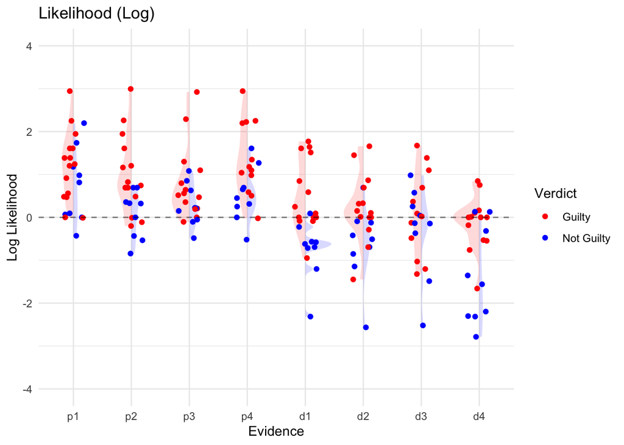

```r
print(p1)
```

```r
print("=== DIAGNOSTIC LOG RATIOS ===")
```

```
## [1] "=== DIAGNOSTIC LOG RATIOS ==="
```

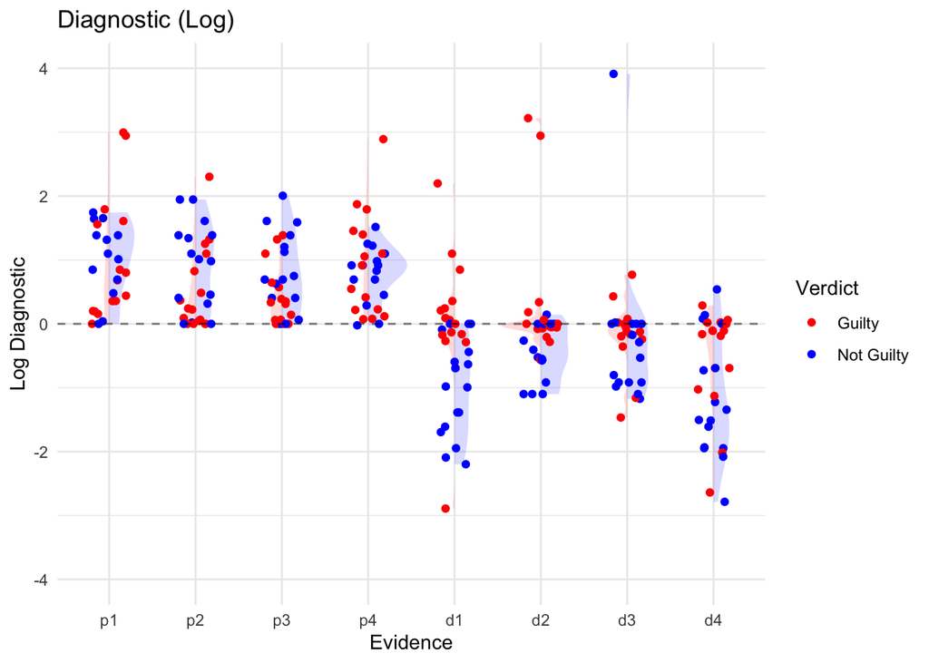

```r
print(p2)
```

```r
print("=== LIKELIHOOD SUBTRACTION ===")
```

```
## [1] "=== LIKELIHOOD SUBTRACTION ==="
```

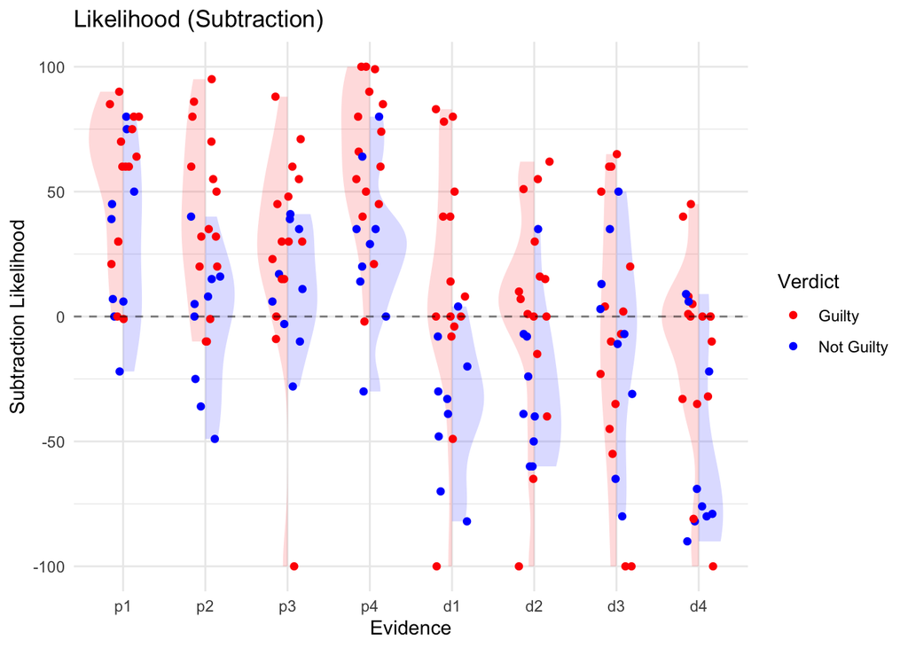

```r
print(p3)
```

```r
print("=== DIAGNOSTIC SUBTRACTION ===")
```

```
## [1] "=== DIAGNOSTIC SUBTRACTION ==="
```

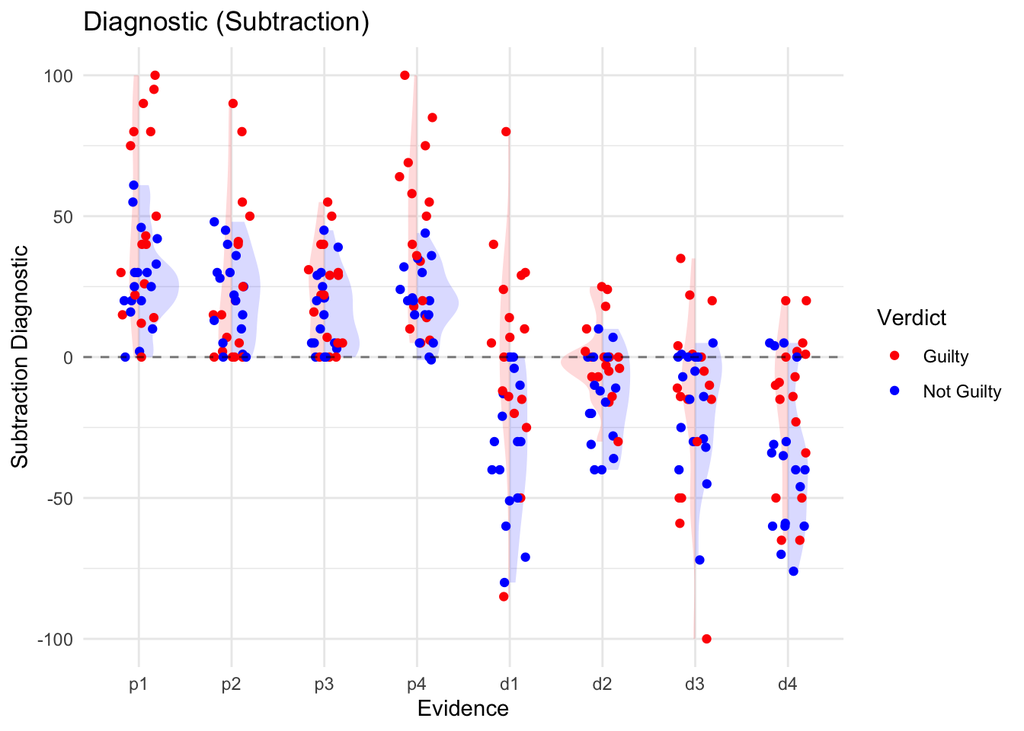

```r
print(p4)
```

# Understand Discrepancy

```r
# Examine some raw numbers to understand the mathematical discrepancy
sample_evidence <- "p1"
sample_data <- diagnostic_data %>%
  filter(!is.na(!!sym(paste0(sample_evidence, "_diagnostic_t")))) %>%
  select(verdict,
         t = !!sym(paste0(sample_evidence, "_diagnostic_t")),
         f = !!sym(paste0(sample_evidence, "_diagnostic_f"))) %>%
  mutate(ratio = t/f,
         log_ratio = log(t/f),
         subtraction = t - f)

guilty_sample <- sample_data %>% filter(verdict == "Guilty")
not_guilty_sample <- sample_data %>% filter(verdict == "Not Guilty")

cat("Sample raw data for", toupper(sample_evidence), ":\n")
```

```
## Sample raw data for P1 :
```

```r
cat("GUILTY verdicts - mean values:\n")
```

```
## GUILTY verdicts - mean values:
```

```r
cat("  P(Evidence|Guilty):", mean(guilty_sample$t, na.rm = TRUE), "\n")
```

```
##   P(Evidence|Guilty): 79.41176
```

```r
cat("  P(Evidence|Not Guilty):", mean(guilty_sample$f, na.rm = TRUE), "\n")
```

```
##   P(Evidence|Not Guilty): 31.64706
```

```r
cat("  Ratio:", mean(guilty_sample$ratio, na.rm = TRUE), "\n")
```

```
##   Ratio: Inf
```

```r
cat("  Subtraction:", mean(guilty_sample$subtraction, na.rm = TRUE), "\n")
```

```
##   Subtraction: 47.76471
```

```r
cat("NOT GUILTY verdicts - mean values:\n")
```

```
## NOT GUILTY verdicts - mean values:
```

```r
cat("  P(Evidence|Guilty):", mean(not_guilty_sample$t, na.rm = TRUE), "\n")
```

```
##   P(Evidence|Guilty): 42.41176
```

```r
cat("  P(Evidence|Not Guilty):", mean(not_guilty_sample$f, na.rm = TRUE), "\n")
```

```
##   P(Evidence|Not Guilty): 15.05882
```

```r
cat("  Ratio:", mean(not_guilty_sample$ratio, na.rm = TRUE), "\n")
```

```
##   Ratio: Inf
```

```r
cat("  Subtraction:", mean(not_guilty_sample$subtraction, na.rm = TRUE), "\n")
```

```
##   Subtraction: 27.35294
```

```r
cat("Differences between verdict groups:\n")
```

```
## Differences between verdict groups:
```

```r
cat("  Ratio difference:", mean(guilty_sample$ratio, na.rm = TRUE) - mean(not_guilty_sample$ratio, na.rm = TRUE), "\n")
```

```
##   Ratio difference: NaN
```

```r
cat("  Subtraction difference:", mean(guilty_sample$subtraction, na.rm = TRUE) - mean(not_guilty_sample$subtraction, na.rm = TRUE), "\n")
```

```
##   Subtraction difference: 20.41176
```

# Explanation of Discrepancy

OK, so this is why we have the discrepancy. Using fingerprint evidence (P1) as an example, participants who voted “guilty” rated the evidence as having a 79.4% probability of occurring if Derek was guilty and a 31.6% probability if Derek was innocent. Participants who voted “not guilty” rated the same evidence as 42.4% likely if guilty and 15.1% likely if innocent.

The subtraction method calculates the difference between these two probability ratings for each participant. Guilty voters showed a mean difference of 47.8 points (79.4 - 31.6), while not-guilty voters showed a mean difference of 27.3 points (42.4 - 15.1). The crucial finding is the between-group difference: 47.8 - 27.3 = 20.5 points. This represents a bias because it captures how differently the two groups weight evidence for guilt versus innocence. Guilty voters see evidence as much more diagnostic of guilt than innocent voters see the same evidence.

When we calculate ratios instead (79.4/31.6 = 2.51 for guilty voters versus 42.4/15.1 = 2.81 for not-guilty voters), the difference between groups becomes much smaller (2.81 - 2.51 = 0.30). This compression occurs because ratios are inherently less sensitive to absolute differences when both the numerator and denominator are in the middle-to-high range. The mathematical properties of division tend to normalize differences, especially when dealing with probability ratings that cluster away from the extreme values of 0 and 100.

# Results Formal Explanation

We conducted a pilot study (N = 58) investigating confirmation bias in legal evidence evaluation using a 2 (reasoning type: likelihood vs. diagnostic) × 2 (verdict: guilty vs. not guilty) mixed design. Participants recruited via Prolific read a burglary case and made initial guilt judgments, then evaluated eight pieces of evidence using either likelihood reasoning (probability of guilt given evidence) or diagnostic reasoning (probability of evidence given guilt status). The likelihood condition included 24 participants (15 guilty, 9 not guilty verdicts), while the diagnostic condition included 34 participants (17 guilty, 17 not guilty verdicts).

We analyzed evidence ratings using two mathematical approaches: (1) log-transformed ratios, following standard Bayesian analysis procedures, and (2) raw difference scores (subtraction method). For likelihood reasoning, we calculated P(Guilty|Evidence True) - P(Guilty|Evidence False). For diagnostic reasoning, we calculated P(Evidence|Guilty) - P(Evidence|Not Guilty). Mixed-design ANOVAs tested for main effects of verdict and evidence type, with pairwise comparisons examining individual evidence items.

The key finding was that confirmation bias detection depended critically on the analytical approach used. Log-ratio analyses revealed minimal effects of verdict on evidence evaluation in both reasoning conditions (likelihood: F(1,22) = 2.28, p = .145; diagnostic: F(1,32) = 1.11, p = .299). These results suggested objective, unbiased evidence processing consistent with normative Bayesian reasoning.

However, subtraction analyses revealed substantial confirmation bias effects in both conditions. For likelihood reasoning, participants who initially judged the defendant guilty showed significantly larger difference scores than those who judged him not guilty (F(1,22) = 13.57, p = .001). For diagnostic reasoning, this bias effect was even stronger (F(1,32) = 20.01, p < .001). Pairwise comparisons showed significant verdict effects for multiple evidence types in both conditions using the subtraction method.

# Type 1 Model: Causal Power + Coherence

## Function to apply diagnostic equations for Type 1 model

```r
apply_causal_power_equations <- function(data, evidence_cols) {

  results_list <- list()

  for(evidence in evidence_cols) {

    cat("Processing evidence:", evidence, "\n")

    # Get the appropriate columns based on condition
    if("diagnostic" %in% unique(data$condition)) {
      # Diagnostic condition: P(Evidence|Guilty) and P(Evidence|Not Guilty)
      p_e_given_g_col <- paste0(evidence, "_diagnostic_t")
      p_e_given_ng_col <- paste0(evidence, "_diagnostic_f")

      # Check if columns exist
      if(p_e_given_g_col %in% names(data) && p_e_given_ng_col %in% names(data)) {

        diagnostic_data <- data %>%
          filter(condition == "diagnostic") %>%
          filter(!is.na(!!sym(p_e_given_g_col)) & !is.na(!!sym(p_e_given_ng_col)))

        if(nrow(diagnostic_data) > 0) {
          # Convert to probabilities (0-1 scale)
          diagnostic_data <- diagnostic_data %>%
            mutate(
              p_e_given_g = !!sym(p_e_given_g_col) / 100,
              p_e_given_ng = !!sym(p_e_given_ng_col) / 100
            )

          # Calculate DelatP (your causal power measure)
          diagnostic_data <- diagnostic_data %>%
            mutate(delta_p = p_e_given_g - p_e_given_ng)

          # Apply your diagnostic equations
          if(evidence %in% c("p1", "p2", "p3", "p4")) {
            # Generative evidence: P(guilty|evidence) = [DeltaP + P(evidence|innocent)] / [DeltaP + 2×P(evidence|innocent)]
            diagnostic_data <- diagnostic_data %>%
              mutate(predicted_guilt = pmax(0.01, pmin(0.99, (delta_p + p_e_given_ng) / (delta_p + 2 * p_e_given_ng))))
          } else {
            # Preventive evidence (d1-d4): P(guilty|no_evidence) = [|DeltaP| + P(no_evidence|innocent)] / [|DeltaP| + 2×P(no_evidence|innocent)]
            diagnostic_data <- diagnostic_data %>%
              mutate(
                p_no_e_given_ng = 1 - p_e_given_ng,
                predicted_guilt = pmax(0.01, pmin(0.99, (abs(delta_p) + p_no_e_given_ng) / (abs(delta_p) + 2 * p_no_e_given_ng)))
              )
          }

          # Convert back to 0-100 scale
          diagnostic_data <- diagnostic_data %>%
            mutate(predicted_guilt_percentage = predicted_guilt * 100)

          # Store results
          results_list[[paste0(evidence, "_diagnostic")]] <- diagnostic_data %>%
            select(id, verdict, delta_p, predicted_guilt, predicted_guilt_percentage, p_e_given_g, p_e_given_ng)
        }
      } else {
        cat("Warning: Columns", p_e_given_g_col, "or", p_e_given_ng_col, "not found for", evidence, "\n")
      }
    }

    if("likelihood" %in% unique(data$condition)) {
      # Likelihood condition: P(Guilty|Evidence True) and P(Guilty|Evidence False)
      p_g_given_e_col <- paste0(evidence, "_likelihood_g")
      p_g_given_ne_col <- paste0(evidence, "_likelihood_ng")

      # Check if columns exist
      if(p_g_given_e_col %in% names(data) && p_g_given_ne_col %in% names(data)) {

        likelihood_data <- data %>%
          filter(condition == "likelihood") %>%
          filter(!is.na(!!sym(p_g_given_e_col)) & !is.na(!!sym(p_g_given_ne_col)))

        if(nrow(likelihood_data) > 0) {
          # These are already the guilt judgments we want to predict
          # We can use them to reverse-engineer the causal power parameters
          likelihood_data <- likelihood_data %>%
            mutate(
              p_g_given_e = !!sym(p_g_given_e_col) / 100,
              p_g_given_ne = !!sym(p_g_given_ne_col) / 100,
              observed_difference = p_g_given_e - p_g_given_ne
            )

          results_list[[paste0(evidence, "_likelihood")]] <- likelihood_data %>%
            select(id, verdict, observed_difference, p_g_given_e, p_g_given_ne)
        }
      } else {
        cat("Warning: Columns", p_g_given_e_col, "or", p_g_given_ne_col, "not found for", evidence, "\n")
      }
    }
  }

  return(results_list)
}
```

## Function to test coherence effects on causal power estimates

```r
test_coherence_on_causal_power <- function(data, evidence_cols) {

  coherence_results <- list()

  # Focus on diagnostic condition where we can measure DeltaP directly
  diagnostic_data <- data %>% filter(condition == "diagnostic")

  if(nrow(diagnostic_data) == 0) {
    cat("Warning: No diagnostic condition data found\n")
    return(coherence_results)
  }

  for(evidence in evidence_cols) {

    t_col <- paste0(evidence, "_diagnostic_t")
    f_col <- paste0(evidence, "_diagnostic_f")

    if(t_col %in% names(diagnostic_data) && f_col %in% names(diagnostic_data)) {

      # Calculate DeltaP for each participant
      test_data <- diagnostic_data %>%
        filter(!is.na(!!sym(t_col)) & !is.na(!!sym(f_col))) %>%
        mutate(delta_p = (!!sym(t_col) - !!sym(f_col)) / 100)

      if(nrow(test_data) > 0) {

        # Test if DeltaP differs by verdict (coherence effect)
        guilty_data <- test_data %>% filter(verdict == "Guilty")
        not_guilty_data <- test_data %>% filter(verdict == "Not Guilty")

        if(nrow(guilty_data) > 0 && nrow(not_guilty_data) > 0) {

          # Statistical test
          t_test_result <- t.test(guilty_data$delta_p, not_guilty_data$delta_p)

          coherence_results[[evidence]] <- list(
            evidence_type = evidence,
            guilty_mean_delta_p = mean(guilty_data$delta_p, na.rm = TRUE),
            not_guilty_mean_delta_p = mean(not_guilty_data$delta_p, na.rm = TRUE),
            coherence_effect = mean(guilty_data$delta_p, na.rm = TRUE) - mean(not_guilty_data$delta_p, na.rm = TRUE),
            p_value = t_test_result$p.value,
            t_statistic = as.numeric(t_test_result$statistic),
            significant = t_test_result$p.value < 0.05,
            n_guilty = nrow(guilty_data),
            n_not_guilty = nrow(not_guilty_data)
          )
        } else {
          cat("Warning: Insufficient data for", evidence, "- Guilty:", nrow(guilty_data), "Not Guilty:", nrow(not_guilty_data), "\n")
        }
      }
    } else {
      cat("Warning: Required columns not found for", evidence, "\n")
    }
  }

  return(coherence_results)
}
```

## Function to combine evidence using likelihood ratios (Type 1 independent combination)

```r
combine_independent_evidence <- function(causal_power_results, participant_data) {

  combined_results <- list()

  # Focus on diagnostic condition results
  diagnostic_results <- causal_power_results[grepl("_diagnostic", names(causal_power_results))]

  if(length(diagnostic_results) > 0) {

    # Get all participant IDs from diagnostic condition
    all_ids <- unique(unlist(lapply(diagnostic_results, function(x) x$id)))

    for(participant_id in all_ids) {

      log_likelihood_ratios <- c()
      individual_predictions <- c()
      evidence_names <- c()

      for(result_name in names(diagnostic_results)) {
        participant_row <- diagnostic_results[[result_name]] %>%
          filter(id == participant_id)

        if(nrow(participant_row) > 0) {
          # Calculate likelihood ratio: P(E|G) / P(E|¬G)
          if(participant_row$p_e_given_ng > 0.01) { # Avoid division by zero
            lr <- participant_row$p_e_given_g / participant_row$p_e_given_ng
            log_lr <- log(lr)
            log_likelihood_ratios <- c(log_likelihood_ratios, log_lr)
            individual_predictions <- c(individual_predictions, participant_row$predicted_guilt_percentage)
            evidence_names <- c(evidence_names, result_name)
          }
        }
      }

      if(length(log_likelihood_ratios) > 0) {
        # Combined log likelihood ratio
        combined_log_lr <- sum(log_likelihood_ratios)

        # Convert back to probability (assuming equal priors)
        combined_odds <- exp(combined_log_lr)
        combined_prob <- combined_odds / (1 + combined_odds)

        # Get participant's actual verdict and probability rating
        participant_actual <- participant_data %>% filter(id == participant_id)

        if(nrow(participant_actual) > 0) {
          combined_results[[paste0("participant_", participant_id)]] <- list(
            participant_id = participant_id,
            verdict = participant_actual$verdict[1],
            actual_probability = participant_actual$probability[1],
            predicted_probability = combined_prob * 100,
            combined_log_lr = combined_log_lr,
            individual_predictions = individual_predictions,
            evidence_names = evidence_names,
            n_evidence_pieces = length(log_likelihood_ratios)
          )
        }
      }
    }
  }

  return(combined_results)
}
```

## Function to calculate model fit statistics

```r
calculate_model_fit <- function(combined_results) {

  if(length(combined_results) == 0) {
    return(list(rmse = NA, mae = NA, correlation = NA, r_squared = NA, n_participants = 0))
  }

  # Extract predictions and actual values
  predictions <- sapply(combined_results, function(x) x$predicted_probability)
  actual <- sapply(combined_results, function(x) x$actual_probability)

  # Remove any NA values
  valid_indices <- !is.na(predictions) & !is.na(actual) & is.finite(predictions) & is.finite(actual)
  predictions <- predictions[valid_indices]
  actual <- actual[valid_indices]

  if(length(predictions) > 2 && length(actual) > 2) {

    # Calculate fit statistics
    rmse <- sqrt(mean((predictions - actual)^2))
    mae <- mean(abs(predictions - actual))
    correlation <- cor(predictions, actual, use = "complete.obs")

    # R-squared
    ss_res <- sum((actual - predictions)^2)
    ss_tot <- sum((actual - mean(actual))^2)
    r_squared <- 1 - (ss_res / ss_tot)

    return(list(
      rmse = rmse,
      mae = mae,
      correlation = correlation,
      r_squared = r_squared,
      n_participants = length(predictions)
    ))
  } else {
    return(list(
      rmse = NA,
      mae = NA,
      correlation = NA,
      r_squared = NA,
      n_participants = length(predictions)
    ))
  }
}
```

## Main Analysis Function

```r
run_type1_causal_power_analysis <- function(data_file_path) {

  # Read data (modify path as needed)
  data <- read.csv(data_file_path)
  names(data) <- trimws(names(data))

  # Evidence pieces
  evidence_cols <- c("p1", "p2", "p3", "p4", "d1", "d2", "d3", "d4")

  cat("=============================================================================")
  cat("TYPE 1 CAUSAL POWER MODEL ANALYSIS")
  cat("=============================================================================")

  cat("Data summary:\n")
  cat("Total participants:", nrow(data), "\n")
  cat("Conditions:", paste(unique(data$condition), collapse = ", "), "\n")
  cat("Verdicts:", paste(unique(data$verdict), collapse = ", "), "\n\n")

  # Step 1: Apply causal power equations
  cat("Step 1: Applying causal power diagnostic equations...\n")
  causal_power_results <- apply_causal_power_equations(data, evidence_cols)
  cat("Completed causal power predictions for", length(causal_power_results), "evidence-condition combinations.\n\n")

  # Step 2: Test coherence effects on causal power estimates
  cat("Step 2: Testing coherence effects on causal power estimates...\n")
  coherence_results <- test_coherence_on_causal_power(data, evidence_cols)

  # Print coherence results
  cat("\nCOHERENCE EFFECTS ON CAUSAL POWER (DeltaP):\n")
  cat("==========================================")
  if(length(coherence_results) > 0) {
    for(evidence in names(coherence_results)) {
      result <- coherence_results[[evidence]]
      cat(sprintf("%s: Guilty mean DeltaP = %.3f, Not Guilty mean DeltaP = %.3f\n",
                  toupper(evidence), result$guilty_mean_delta_p, result$not_guilty_mean_delta_p))
      cat(sprintf("      Coherence effect = %.3f, t = %.3f, p = %.3f %s\n",
                  result$coherence_effect, result$t_statistic, result$p_value,
                  ifelse(result$significant, "***", "")))
      cat(sprintf("      Sample sizes: Guilty = %d, Not Guilty = %d\n\n",
                  result$n_guilty, result$n_not_guilty))
    }
  } else {
    cat("No coherence results found. Check data structure.\n\n")
  }

  # Step 3: Combine evidence using Type 1 independent mechanisms
  cat("Step 3: Combining evidence using independent mechanism assumption...\n")
  combined_results <- combine_independent_evidence(causal_power_results, data)
  cat("Completed evidence combination for", length(combined_results), "participants.\n\n")

  # Step 4: Calculate model fit
  cat("Step 4: Calculating model fit statistics...\n")
  model_fit <- calculate_model_fit(combined_results)

  cat("\nMODEL FIT STATISTICS:\n")
  cat("=====================\n")
  if(!is.na(model_fit$rmse)) {
    cat(sprintf("RMSE: %.2f\n", model_fit$rmse))
    cat(sprintf("MAE: %.2f\n", model_fit$mae))
    cat(sprintf("Correlation: %.3f\n", model_fit$correlation))
    cat(sprintf("R-squared: %.3f\n", model_fit$r_squared))
  } else {
    cat("Model fit could not be calculated (insufficient valid predictions)\n")
  }
  cat(sprintf("N participants: %d\n\n", model_fit$n_participants))

  # Step 5: Create summary data frame for further analysis
  if(length(coherence_results) > 0) {
    summary_df <- data.frame(
      evidence = names(coherence_results),
      guilty_mean_delta_p = sapply(coherence_results, function(x) x$guilty_mean_delta_p),
      not_guilty_mean_delta_p = sapply(coherence_results, function(x) x$not_guilty_mean_delta_p),
      coherence_effect = sapply(coherence_results, function(x) x$coherence_effect),
      p_value = sapply(coherence_results, function(x) x$p_value),
      significant = sapply(coherence_results, function(x) x$significant),
      stringsAsFactors = FALSE
    )
  } else {
    summary_df <- data.frame()
  }

  # Return everything for further analysis
  return(list(
    causal_power_results = causal_power_results,
    coherence_results = coherence_results,
    combined_results = combined_results,
    model_fit = model_fit,
    summary_df = summary_df,
    data = data
  ))
}
```

## Visualization Function

```r
plot_coherence_effects <- function(analysis_results) {

  plots_list <- list()

  if(nrow(analysis_results$summary_df) > 0) {
    summary_df <- analysis_results$summary_df

    # Plot 1: Coherence effects by evidence type
    p1 <- ggplot(summary_df, aes(x = evidence, y = coherence_effect)) +
      geom_col(aes(fill = significant), alpha = 0.7) +
      geom_hline(yintercept = 0, linetype = "dashed") +
      scale_fill_manual(values = c("FALSE" = "gray", "TRUE" = "red")) +
      labs(title = "Coherence Effects on Causal Power (DeltaP)",
           subtitle = "Difference in DeltaP between Guilty and Not Guilty voters",
           x = "Evidence Type",
           y = "Coherence Effect (Guilty DeltaP - Not Guilty DeltaP)",
           fill = "Significant") +
      theme_minimal() +
      theme(axis.text.x = element_text(angle = 45, hjust = 1))

    plots_list$coherence_plot <- p1
    print(p1)
  }

  # Plot 2: Actual vs Predicted guilt judgments
  if(length(analysis_results$combined_results) > 0) {

    prediction_df <- data.frame(
      predicted = sapply(analysis_results$combined_results, function(x) x$predicted_probability),
      actual = sapply(analysis_results$combined_results, function(x) x$actual_probability),
      verdict = sapply(analysis_results$combined_results, function(x) x$verdict)
    )

    # Remove any invalid values
    prediction_df <- prediction_df %>%
      filter(!is.na(predicted) & !is.na(actual) & is.finite(predicted) & is.finite(actual))

    if(nrow(prediction_df) > 0) {
      p2 <- ggplot(prediction_df, aes(x = predicted, y = actual)) +
        geom_point(aes(color = verdict), alpha = 0.6) +
        geom_smooth(method = "lm", se = TRUE, color = "black") +
        geom_abline(intercept = 0, slope = 1, linetype = "dashed", alpha = 0.5) +
        scale_color_manual(values = c("Guilty" = "red", "Not Guilty" = "blue")) +
        labs(title = "Causal Power Model: Predicted vs Actual Guilt Judgments",
             x = "Predicted Probability of Guilt (%)",
             y = "Actual Probability of Guilt (%)",
             color = "Verdict") +
        theme_minimal() +
        coord_fixed()

      plots_list$prediction_plot <- p2
      print(p2)
    }
  }

  return(plots_list)
}
```

# Run Causal Model Power

```r
type1_results <- run_type1_causal_power_analysis("/Users/dgkamper/Library/CloudStorage/GoogleDrive-dgkamper@gmail.com/My Drive/DGK Lab/Collaborations/Causal Cognition Lab/Causal Cognition Lab; Reasoning Lab - Constrain Satisfaction Causal Models/Data/clean data.csv")
```

```
## =============================================================================TYPE 1 CAUSAL POWER MODEL ANALYSIS=============================================================================Data summary:
## Total participants: 58
## Conditions: likelihood, diagnostic
## Verdicts: Guilty, Not Guilty
##
## Step 1: Applying causal power diagnostic equations...
## Processing evidence: p1
## Processing evidence: p2
## Processing evidence: p3
## Processing evidence: p4
## Processing evidence: d1
## Processing evidence: d2
## Processing evidence: d3
## Processing evidence: d4
## Completed causal power predictions for 16 evidence-condition combinations.
##
## Step 2: Testing coherence effects on causal power estimates...
##
## COHERENCE EFFECTS ON CAUSAL POWER (DeltaP):
## ==========================================P1: Guilty mean DeltaP = 0.478, Not Guilty mean DeltaP = 0.274
##       Coherence effect = 0.204, t = 2.299, p = 0.031 ***
##       Sample sizes: Guilty = 17, Not Guilty = 17
##
## P2: Guilty mean DeltaP = 0.262, Not Guilty mean DeltaP = 0.216
##       Coherence effect = 0.045, t = 0.572, p = 0.573
##       Sample sizes: Guilty = 17, Not Guilty = 17
##
## P3: Guilty mean DeltaP = 0.224, Not Guilty mean DeltaP = 0.161
##       Coherence effect = 0.064, t = 1.152, p = 0.258
##       Sample sizes: Guilty = 17, Not Guilty = 17
##
## P4: Guilty mean DeltaP = 0.435, Not Guilty mean DeltaP = 0.198
##       Coherence effect = 0.237, t = 3.063, p = 0.006 ***
##       Sample sizes: Guilty = 17, Not Guilty = 17
##
## D1: Guilty mean DeltaP = 0.011, Not Guilty mean DeltaP = -0.312
##       Coherence effect = 0.322, t = 2.961, p = 0.006 ***
##       Sample sizes: Guilty = 17, Not Guilty = 17
##
## D2: Guilty mean DeltaP = -0.004, Not Guilty mean DeltaP = -0.145
```

[output cut: 8 more lines]

```
##       Coherence effect = 0.196, t = 2.131, p = 0.041 ***
##       Sample sizes: Guilty = 17, Not Guilty = 17
##
## Step 3: Combining evidence using independent mechanism assumption...
## Completed evidence combination for 34 participants.
##
## Step 4: Calculating model fit statistics...
##
## MODEL FIT STATISTICS:
## =====================
## RMSE: 31.17
## MAE: 25.79
## Correlation: 0.374
## R-squared: -0.753
## N participants: 34
```

```r
# Display results
print(type1_results$summary_df)
```

```
##    evidence guilty_mean_delta_p not_guilty_mean_delta_p coherence_effect
## p1       p1         0.477647059               0.2735294       0.20411765
## p2       p2         0.261764706               0.2164706       0.04529412
## p3       p3         0.224117647               0.1605882       0.06352941
## p4       p4         0.434705882               0.1976471       0.23705882
## d1       d1         0.010588235              -0.3117647       0.32235294
## d2       d2        -0.004117647              -0.1452941       0.14117647
## d3       d3        -0.162941176              -0.1811765       0.01823529
## d4       d4        -0.172941176              -0.3688235       0.19588235
##        p_value significant
## p1 0.030547577        TRUE
## p2 0.572806447       FALSE
## p3 0.258242573       FALSE
## p4 0.005675272        TRUE
## d1 0.006145764        TRUE
## d2 0.010659374        TRUE
## d3 0.850643182       FALSE
## d4 0.040890309        TRUE
```

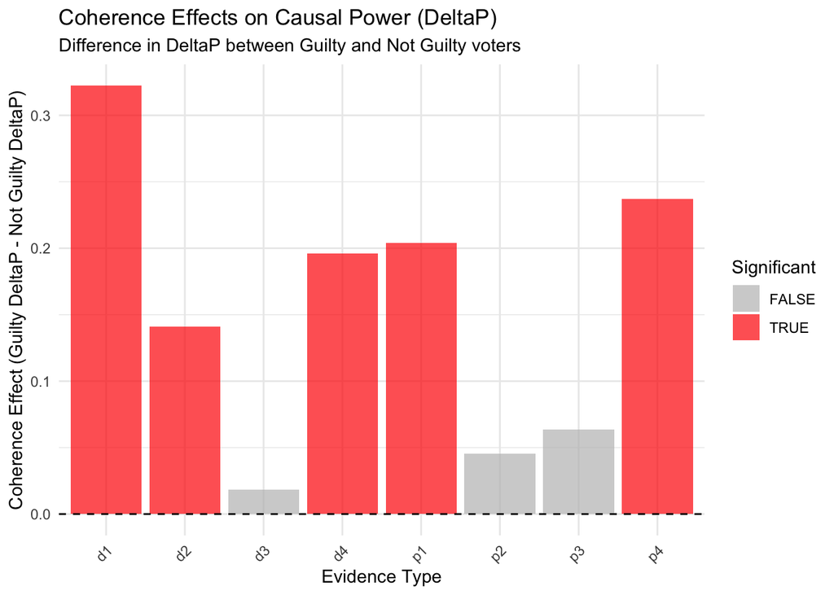

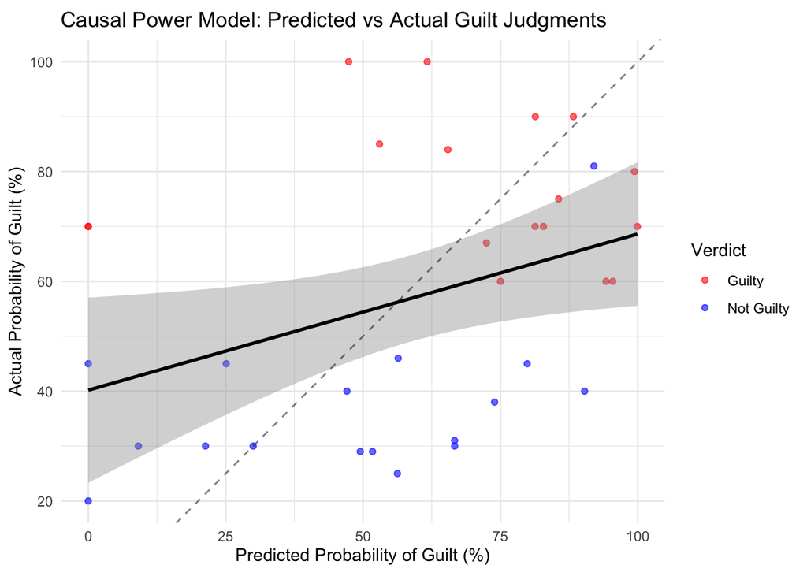

```r
# Create and display plots
type1_plots <- plot_coherence_effects(type1_results)
```

# Comparie Type 1 to Subtraction

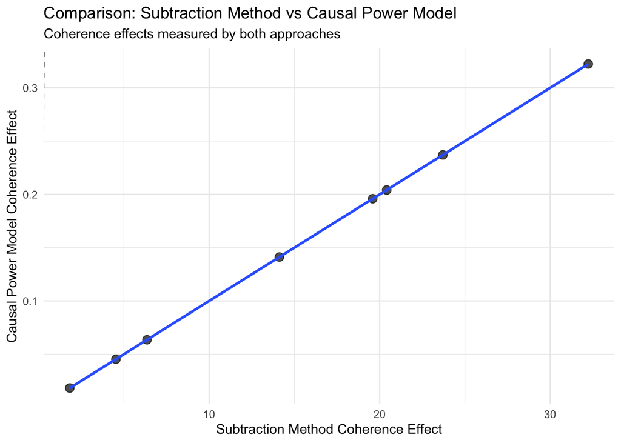

```r
# Your existing coherence analysis using subtraction method
existing_subtraction_results <- diagnostic_subtraction_results  # From your existing code

# Create comparison
comparison_results <- data.frame(
  evidence = names(existing_subtraction_results),
  subtraction_coherence_effect = sapply(existing_subtraction_results, function(x) {
    guilty_mean <- x$mean_subtraction[x$verdict == "Guilty"]
    not_guilty_mean <- x$mean_subtraction[x$verdict == "Not Guilty"]
    guilty_mean - not_guilty_mean
  }),
  causal_power_coherence_effect = type1_results$summary_df$coherence_effect,
  stringsAsFactors = FALSE
)

# Plot comparison
comparison_plot <- ggplot(comparison_results, aes(x = subtraction_coherence_effect, y = causal_power_coherence_effect)) +
  geom_point(size = 3, alpha = 0.7) +
  geom_smooth(method = "lm", se = TRUE) +
  geom_abline(intercept = 0, slope = 1, linetype = "dashed", alpha = 0.5) +
  labs(title = "Comparison: Subtraction Method vs Causal Power Model",
       subtitle = "Coherence effects measured by both approaches",
       x = "Subtraction Method Coherence Effect",
       y = "Causal Power Model Coherence Effect") +
  theme_minimal()

print(comparison_plot)
```

```r
# Calculate correlation between the two methods
method_correlation <- cor(comparison_results$subtraction_coherence_effect,
                         comparison_results$causal_power_coherence_effect,
                         use = "complete.obs")

cat(sprintf("\nCorrelation between subtraction method and causal power method: %.3f\n", method_correlation))
```

```
##
## Correlation between subtraction method and causal power method: 1.000
```

# Individual Evidence

```
##
## === DETAILED ANALYSIS FOR P1 ===
## # A tibble: 2 × 6
##   verdict      n mean_delta_p sd_delta_p mean_predicted_guilt sd_predicted_guilt
##   <chr>    <int>        <dbl>      <dbl>                <dbl>              <dbl>
## 1 Guilty      17        0.478      0.325                0.742              0.169
## 2 Not Gui…    17        0.274      0.168                0.786              0.156
```

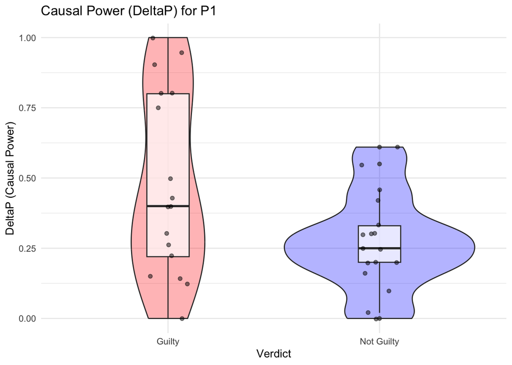

```
##
## === DETAILED ANALYSIS FOR P2 ===
## # A tibble: 2 × 6
##   verdict      n mean_delta_p sd_delta_p mean_predicted_guilt sd_predicted_guilt
##   <chr>    <int>        <dbl>      <dbl>                <dbl>              <dbl>
## 1 Guilty      17        0.262      0.287                0.643              0.157
## 2 Not Gui…    17        0.216      0.156                0.748              0.154
```

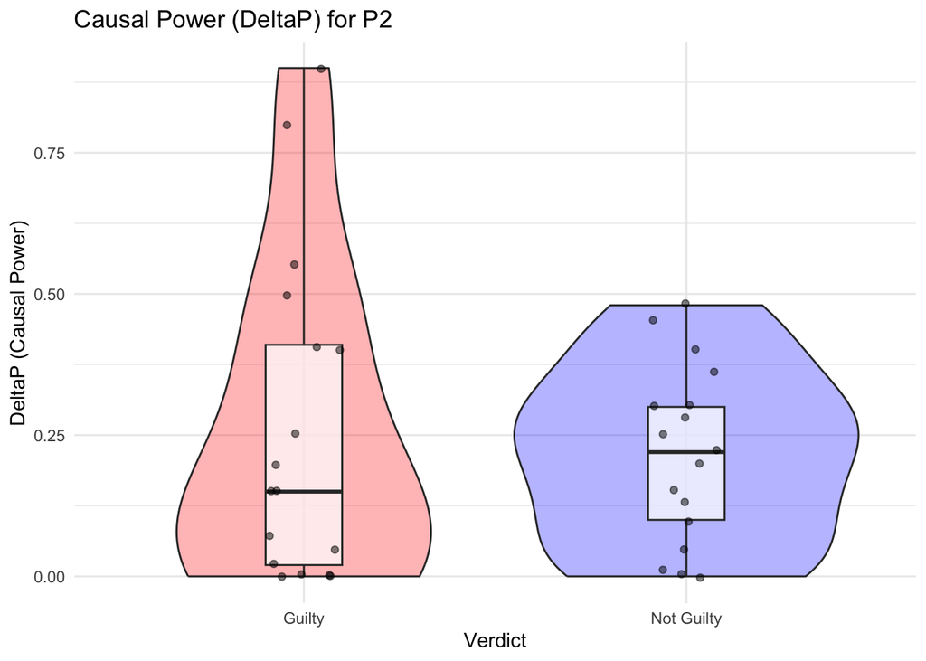

```
##
## === DETAILED ANALYSIS FOR P3 ===
## # A tibble: 2 × 6
##   verdict      n mean_delta_p sd_delta_p mean_predicted_guilt sd_predicted_guilt
##   <chr>    <int>        <dbl>      <dbl>                <dbl>              <dbl>
## 1 Guilty      17        0.224      0.178                0.649              0.161
## 2 Not Gui…    17        0.161      0.142                0.702              0.143
```

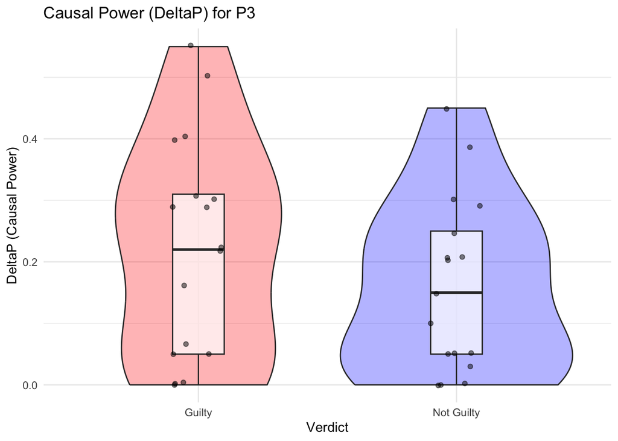

```
##
## === DETAILED ANALYSIS FOR P4 ===
## # A tibble: 2 × 6
##   verdict      n mean_delta_p sd_delta_p mean_predicted_guilt sd_predicted_guilt
##   <chr>    <int>        <dbl>      <dbl>                <dbl>              <dbl>
## 1 Guilty      17        0.435      0.292                0.728              0.167
## 2 Not Gui…    17        0.198      0.129                0.716              0.137
```

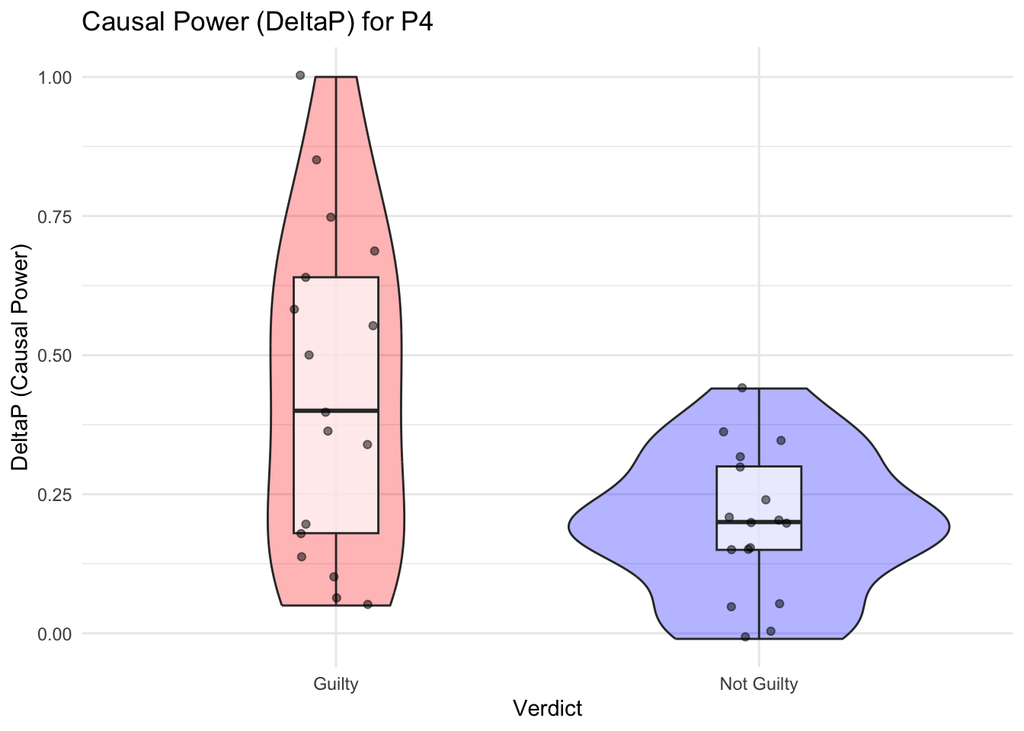

```
##
## === DETAILED ANALYSIS FOR D1 ===
## # A tibble: 2 × 6
##   verdict      n mean_delta_p sd_delta_p mean_predicted_guilt sd_predicted_guilt
##   <chr>    <int>        <dbl>      <dbl>                <dbl>              <dbl>
## 1 Guilty      17       0.0106      0.371                0.695              0.175
## 2 Not Gui…    17      -0.312       0.253                0.639              0.126
```

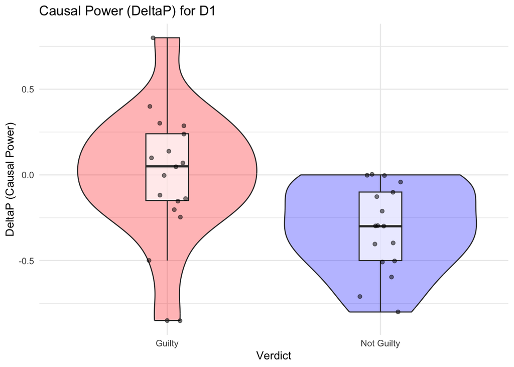

```
##
## === DETAILED ANALYSIS FOR D2 ===
## # A tibble: 2 × 6
##   verdict      n mean_delta_p sd_delta_p mean_predicted_guilt sd_predicted_guilt
##   <chr>    <int>        <dbl>      <dbl>                <dbl>              <dbl>
## 1 Guilty      17     -0.00412      0.140                0.586             0.117
## 2 Not Gui…    17     -0.145        0.162                0.566             0.0622
```

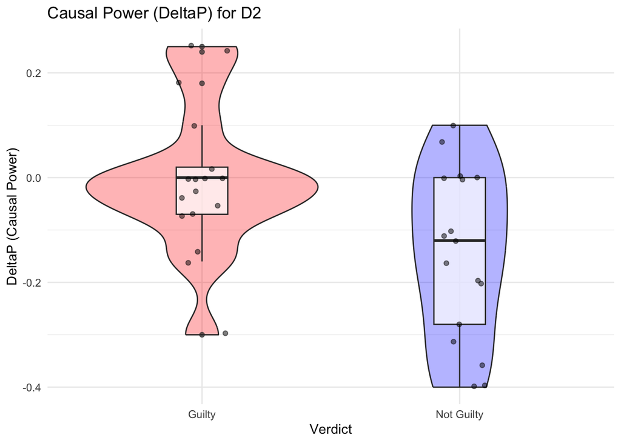

```
##
## === DETAILED ANALYSIS FOR D3 ===
## # A tibble: 2 × 6
##   verdict      n mean_delta_p sd_delta_p mean_predicted_guilt sd_predicted_guilt
##   <chr>    <int>        <dbl>      <dbl>                <dbl>              <dbl>
## 1 Guilty      17       -0.163      0.334                0.696             0.170
## 2 Not Gui…    17       -0.181      0.211                0.575             0.0874
```

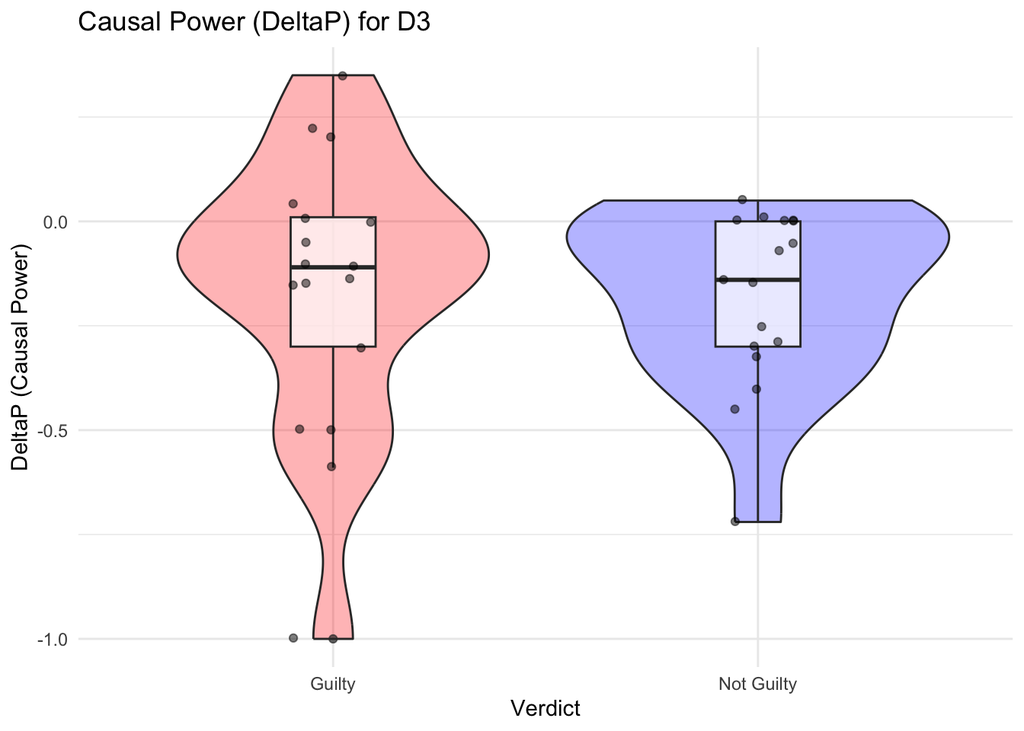

```
##
## === DETAILED ANALYSIS FOR D4 ===
## # A tibble: 2 × 6
##   verdict      n mean_delta_p sd_delta_p mean_predicted_guilt sd_predicted_guilt
##   <chr>    <int>        <dbl>      <dbl>                <dbl>              <dbl>
## 1 Guilty      17       -0.173      0.268                0.680              0.170
## 2 Not Gui…    17       -0.369      0.268                0.668              0.121
```

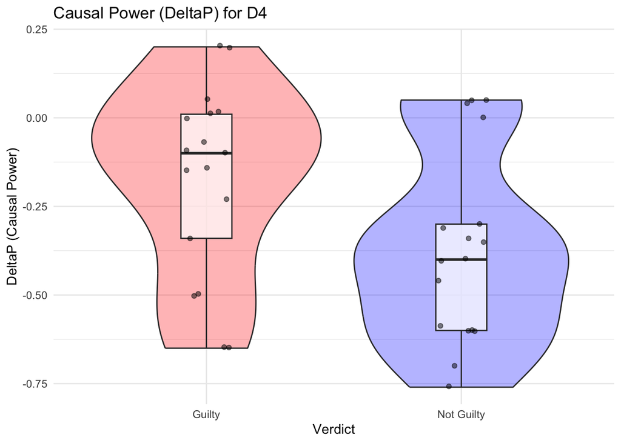

```r
# Analyze each evidence piece in detail
for(evidence in evidence_cols) {

  cat(sprintf("\n=== DETAILED ANALYSIS FOR %s ===\n", toupper(evidence)))

  if(paste0(evidence, "_diagnostic") %in% names(type1_results$causal_power_results)) {

    evidence_data <- type1_results$causal_power_results[[paste0(evidence, "_diagnostic")]]

    # Summary statistics by verdict
    summary_stats <- evidence_data %>%
      group_by(verdict) %>%
      summarise(
        n = n(),
        mean_delta_p = mean(delta_p, na.rm = TRUE),
        sd_delta_p = sd(delta_p, na.rm = TRUE),
        mean_predicted_guilt = mean(predicted_guilt, na.rm = TRUE),
        sd_predicted_guilt = sd(predicted_guilt, na.rm = TRUE),
        .groups = 'drop'
      )

    print(summary_stats)

    # Individual evidence plot
    evidence_plot <- ggplot(evidence_data, aes(x = verdict, y = delta_p)) +
      geom_violin(alpha = 0.3, aes(fill = verdict)) +
      geom_boxplot(width = 0.2, alpha = 0.7) +
      geom_jitter(width = 0.1, alpha = 0.5) +
      scale_fill_manual(values = c("Guilty" = "red", "Not Guilty" = "blue")) +
      labs(title = paste("Causal Power (DeltaP) for", toupper(evidence)),
           y = "DeltaP (Causal Power)",
           x = "Verdict") +
      theme_minimal() +
      guides(fill = "none")

    print(evidence_plot)
  }
}
```

# Prediction Analysis

```
##
## === PREDICTION ACCURACY BY VERDICT ===
## # A tibble: 2 × 5
##   verdict        n mean_absolute_error  rmse correlation
##   <chr>      <int>               <dbl> <dbl>       <dbl>
## 1 Guilty        17                27.4  34.2      -0.125
## 2 Not Guilty    17                24.2  27.8       0.442
```

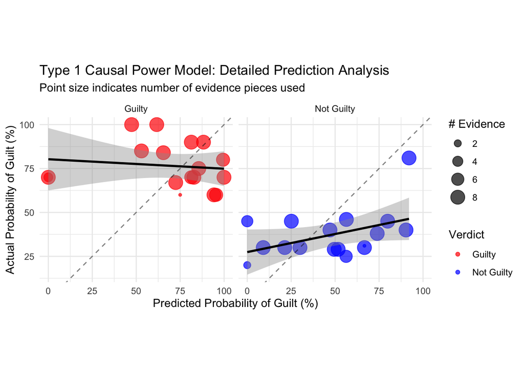

```r
if(length(type1_results$combined_results) > 0) {

  # Create detailed prediction comparison
  prediction_comparison <- data.frame(
    participant_id = sapply(type1_results$combined_results, function(x) x$participant_id),
    verdict = sapply(type1_results$combined_results, function(x) x$verdict),
    actual_probability = sapply(type1_results$combined_results, function(x) x$actual_probability),
    predicted_probability = sapply(type1_results$combined_results, function(x) x$predicted_probability),
    absolute_error = abs(sapply(type1_results$combined_results, function(x) x$actual_probability - x$predicted_probability)),
    n_evidence_pieces = sapply(type1_results$combined_results, function(x) x$n_evidence_pieces)
  )

  # Prediction accuracy by verdict
  accuracy_by_verdict <- prediction_comparison %>%
    group_by(verdict) %>%
    summarise(
      n = n(),
      mean_absolute_error = mean(absolute_error, na.rm = TRUE),
      rmse = sqrt(mean((actual_probability - predicted_probability)^2, na.rm = TRUE)),
      correlation = cor(actual_probability, predicted_probability, use = "complete.obs"),
      .groups = 'drop'
    )

  cat("\n=== PREDICTION ACCURACY BY VERDICT ===\n")
  print(accuracy_by_verdict)

  # Detailed prediction plot
  detailed_prediction_plot <- ggplot(prediction_comparison, aes(x = predicted_probability, y = actual_probability)) +
    geom_point(aes(color = verdict, size = n_evidence_pieces), alpha = 0.7) +
    geom_smooth(method = "lm", se = TRUE, color = "black") +
    geom_abline(intercept = 0, slope = 1, linetype = "dashed", alpha = 0.5) +
    facet_wrap(~verdict) +
    scale_color_manual(values = c("Guilty" = "red", "Not Guilty" = "blue")) +
    labs(title = "Type 1 Causal Power Model: Detailed Prediction Analysis",
         subtitle = "Point size indicates number of evidence pieces used",
         x = "Predicted Probability of Guilt (%)",
         y = "Actual Probability of Guilt (%)",
         color = "Verdict",
         size = "# Evidence") +
    theme_minimal() +
    coord_fixed()

  print(detailed_prediction_plot)
}
```